# Team Assignment 1

Group 6

# 1. Introduction

This report aims to understand the market of four chosen fast-moving consumer goods (FMCG) products in the Italian market. Two product categories , i.e. crackers and dry cookies, are provided in the dataset. Of the 17 brands, four brands from the crackers category, i.e. `Product 2`, `Product 3`, `Product 4`, and `Product 6`, are selected to be further analysed. The first step will be to conduct a preliminary analysis of each product. This will allow to form initial hypotheses about the different positions of the brands in the market as well as the market structure. After the initial analysis, we will attempt to detect the promotional periods using a combination of algorithmic and visual apporach. Then, the own and cross-price elasticities will be calculated to assess the clout and vulnerability of each brand. Finally, the report will conclude with a discussion of the results and insights gained abouut the Italian cracker market.

# 2. Preliminary Analysis

Average Price and Volume

|  | Average Price | Average Volume |
| --- | --- | --- |
| Product 2 | 2.663 | 94527.33 |
| Product 3 | 5.278 | 84788.64 |
| Product 4 | 6.737 | 47015.71 |
| Product 6 | 5.311 | 33132.16 |

*Table 1: Average price and sales volume for each brand.*

With this preliminary analysis we expect to see brands with lower prices have a relatively higher own price elasticity than brands with higher prices. We also expect brands with relatively lower prices to be more vulnerable and mid-ranged brands to have the highest clout.

# 3. Promotion Detection

In order to calculate elasticites, we need to isolate the effect of promotions on volume. The first apporach used to detect promtional periods was to use the average price ($\bar{P}_i$) and standard deviation ($\sigma_i$) of each brand to create a price promotion threshold. Any period with a price below one standard deviation from the average was seen as a promotional period. This method of promotion detection was supplemented with a visual approach. Here, periods that showed high sales volumes were also considered promotional periods. Rather than being price promotions, these are likely to be special end of aisle displays or features the brands engage in. If included in the data set, gross rating point (GRP) was encoded advertising period rather than promotional period.

(((After separating all possible factors that could affect the price and volume, we need to verify the effect of promotion and discount for each product. This can be obtained by calculating the baseline sales volume and the lift. We estimate the weeks where there were advertising campaign for all products, particularly the two products without GRP data, to get the best representation of when the lift occurred. )))

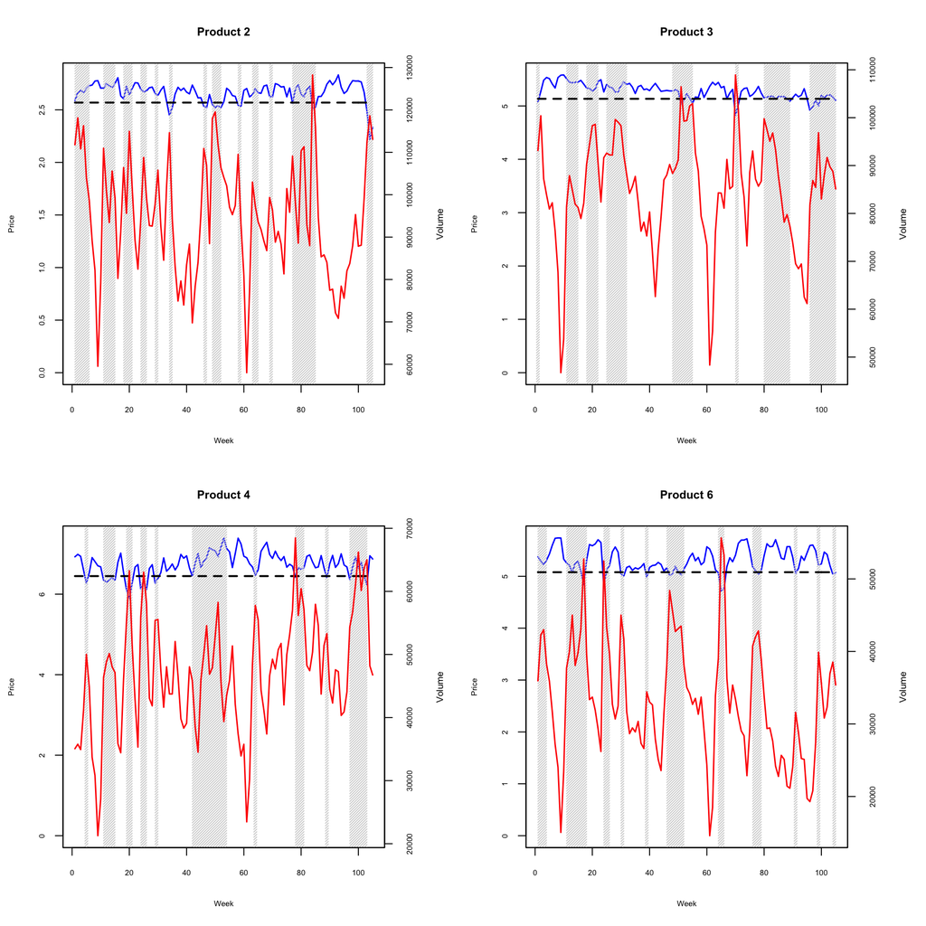

*Chart 1: Price (blue), sales volume (red), promotion (gray), price promotion threshold (black dashed). Note: The y-axes are of different scales.*

The four different brands display different promotional behaviors (above). `Product 2`, for example, engages in many short promotional periods which were identified as flash sales. `Product 3` appears to favor longer periods of promotion. `Product 4` and `Product 6` display a mixture of both behaviors. The effectiveness of the respective brands promotions vary greatly across the given time period with some promotions boosting sales by as much as 40% and others by as little as 15%.

# 4. Baseline and Lift Calculation

The four relevant factors affecting volume of sales are being regressed to the volume of sales by a linear model. However, only significant factors need to be included in the model hence automatic model selection are performed to select best linear model. Lastly, using the best model selected, volume baseline is derived by putting the values of independent variables into the model.

Besides volume baseline, for promotional periods there are usually lift in sales. Lift in the volume of sales is basically indicates how much the volume of sales increased from its baseline as an effect of promotions. Hence lift is calculated by subtracting actual volume with volume baseline.

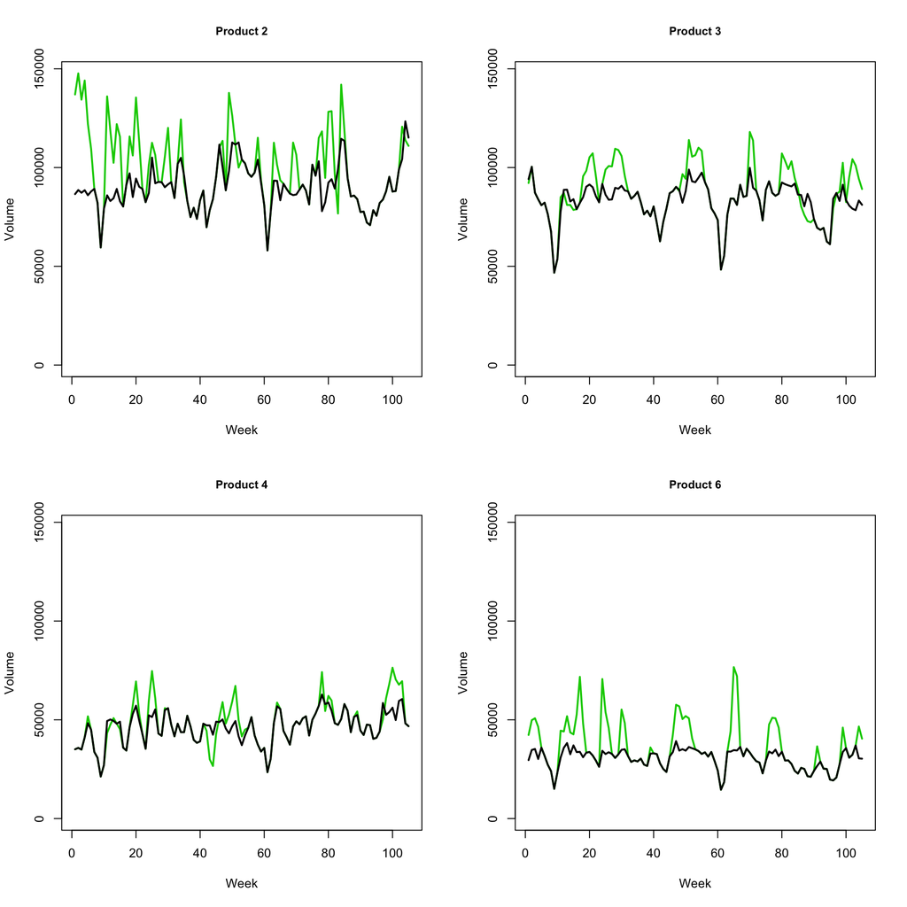

The four brands show different effectiveness in their promotions (above). `Product 2` has the most successful promotional periods large added volume to its baseline sales. This stands in stark contrast to `Product 3` and `Product 4`, which see relatively smaller efffectiveness from their promotions. `Product 6` sees the most balanced effect from promotions. This is likely due its the relatively regular baseline sales compared to other brands.

# 5. Regression Model

To calculate own and cross price elasticities for each brand we built models with different functional forms (linear, semi-log, and log-log). The dependent variable is `volume` and `price`, `ad` (averstizing) and `promo` (promotion) are the first three independent variables. Then, information about the competition was added to account for their potential effects. For the Semi-Log form we use the log of `volume` as independent variable while the predictors stay the same. For the log-log model, we use the log of `volume` as independent variable as well as log forms for `price`. The general models look as follows:

Linear:

$$\begin{eqnarray*}
\ {volume_i} = & a_0 + a_1 price_i + a_2 ad_i + a_3 promo_i + \sum_{j} (b_1 price_j + b_2 ad_j + b_3 promo_j)
\end{eqnarray*}$$

Semi-log:

$$\begin{eqnarray*}
\ {log(volume_i)} = & a_0 + a_1 price_i + a_2 ad_i + a_3 promo_i + \sum_{j} (b_1 price_j + b_2 ad_j + b_3 promo_j)
\end{eqnarray*}$$

Log-log:

$$\begin{eqnarray*}
\ {log(volume_i)} = & a_0 + a_1 log(price_i) + a_2 ad_i + a_3 promo_i + \sum_{j} (b_1 log(price_j) + b_2 ad_j + b_3 promo_j)
\end{eqnarray*}$$

For each model, every combination of predictors was evaluated using a stepwize selection algorithm. The best models for each functional form were then compared by their root mean squared error (RMSE). The model with the lowest RMSE was selected to calculate own and cross-price elasticities.

# 6. Results and Discussion

The best model for product `Product 2` and `Product 6` were the linear models. The best models `Product 3` and `Product 4` were semi-log and log-log respectively. The formulas used to calculate elasticities look as follows:

$$\begin{eqnarray*}
e_{ii} = a_1 \times \frac{\bar{P}_i}{\bar{Q}_i} \\
e_{ij} = b_1 \times \frac{\bar{P}_j}{\bar{Q}_i}
\end{eqnarray*}$$

The Semi-Log model for `Product 3` has the lowest RMSE amongst the three. The price elasticity formula is expressed below.

$$\begin{eqnarray*}
e_{ii} = a_1 \times \bar{P}_i \\
e_{ij} = b_1 \times \bar{P}_j
\end{eqnarray*}$$

The best model for `Product 4` is the Log-Log model. Hence, the elasticities are the coefficient of the corresponding price variables. Then, the elasticity matrix and the clout and vulnerability of each product are shown below.

The price elasticity of each product seems suitable for FMCG products. Their demand are elastic as expected from the market where there are many alternatives. However, the market has different products that appeals several customer segments. Usign the clout and vulnerability table, we could locate the position of each brand within the market.

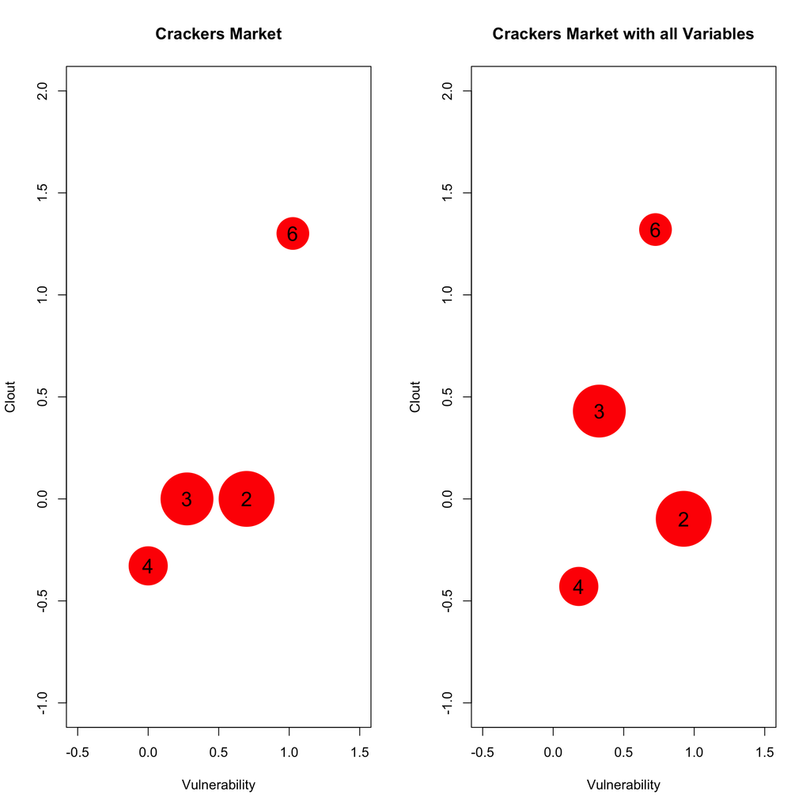

|  | Product 2 | Product 3 | Product 4 | Product 6 |
| --- | --- | --- | --- | --- |
| Product 2 | -1.99 | 0.000 | -0.328 | 1.026 |
| Product 3 | 0.00 | -2.094 | 0.000 | 0.275 |
| Product 4 | 0.00 | 0.000 | -3.020 | 0.000 |
| Product 6 | 0.00 | 0.000 | 0.000 | -2.319 |

|  | Product 2 | Product 3 | Product 4 | Product 6 |
| --- | --- | --- | --- | --- |
| Product 2 | -2.223 | 0.353 | -0.323 | 0.896 |
| Product 3 | -0.016 | -2.169 | -0.018 | 0.362 |
| Product 4 | 0.002 | 0.117 | -2.909 | 0.063 |
| Product 6 | -0.083 | -0.040 | -0.088 | -2.320 |

When examining the elasticity matrices, we notice a number of trends. In the elasticity matrix calculated with all potential variables, even those that are insignificant at a 5% significance level, we notice that products 2, 3, and 6 have similar elasticities. With a price elasticity of around -2.2, these crackers are quite elastic to demand. Product 4 has a much higher price elasticity at -2.9087613. As a more premium good, its sales are more price sensitive as consumers may be inclined to switch to it when it does not have as much of a price premium. Conversely, when product 4 increases its price, customers do not buy it because they cannot justify the even higher price premium.

With regards to the cross elasticities, many of the products have not effect on each other as their prices change. While there exist a few negative cross elasticities, most of them are essentially 0 so we can treat them as such. Notable cross elasticities include product 6’s effect on product 3. As two similarly priced products, when the niche product 6 lowers in price, product 3’s sales suffer. Customers may be incentivized to try the niche product at a lower price point, compared to the simlarly priced standard crackers. A similar effect occurs with product 3’s effect on product 2. When product 3’s price drops, the low price option of product 2 has less sales. Customers are willing to upgrade to a higher priced product when the price difference is not as much. Product 6 has a very strong effect on the volume of product 2 as well. This is the same effect as with product 3, but not the additional niche factor of product 6 comes into play. Customers are quite likely to try the niche crackers when they are not much more expensive than the standard cheap crackers. Finally, it is interesting to note that product 4’s effect on product 2 is actually negative, with a cross elasticity of -0.3234974. This means that as product 4, the expensive crackers, and product 2, the cheap crackers, can be seen as somewhat complementary goods. As product 4’s price decreases, product 2’s sales volume actually increases. This could potentially make sense because people see the expensive cracker on sale, but upon further examination end up purchasing the cheap creacker. The negative cross price elasticity could also arise due to inconsistencies when aggregating the data to a weekly level. The aggregation would mask sales and promotions that could only be seen on a more detailed level, such as with daily store level sales data.

When analyzing the clout and vulnerability matrices, we examine both the scenario where we include insignificant predictors and the one where only significant predictors are included. When we include all predictors, we see that product 2 has low clout and high vulnerability. This makes sense because it is a low priced good that people only buy when they cannot afford the more expensive options. This product competes solely on price. Product 3 has a higher clout and lower vulnerability. As the standard offering, it can somewhat affect the sales of other products but is also vulnerable to their price changes. Product 4, the high priced offering has a very low vulnerability and also low clout. Because no crackers operate in the premium market is is not vulnerable to poaching customers. Premium customers will only buy product 4. Conversely, because it is a premium product it cannot change the sales of the other products because only premium customers buy product 4. Finally, product 6 has a high clout and high vulnerability. As a niche offering, its price changes can alter its sales volumes significantly. These changes will directly affect the lower priced offerings in the market. However, it is also quite vulnerable because people will only purchase a niche cracker when it has a notable price advantage relative to the standard offerings.

# 7. Conclusion